# majority_vs_minority_welfare

This notebook is part of a broader set of experiments on what shapes overall welfare, majority welfare, and minority welfare in spatial elections.

The goal is not just to compare electoral rules in the abstract. It is to see how those three welfare objects move when several politically meaningful ingredients change at the same time: party sorting, primary rules, turnout, strategic voting, group size, candidate supply, and the general-election system.

The underlying comparison space is

`electorate × primaries × turnout × strategy × majority:minority ratio × candidate slate × system`

but the notebook does not run the full discrete cross-product. Instead it uses a **mixed Latin hypercube design**. That means the notebook spreads sampled cases evenly over the continuous parts of the setup, while still drawing from the discrete institutional choices like the primary pipeline, turnout profile, strategy profile, and candidate slate. Later, it uses simple regression summaries to ask which ingredients are most associated with changes in overall, majority, and minority welfare.

Plurality stays in the notebook throughout as the baseline. That is important here. The point is not just to compare systems to one another in the abstract, but to see when they do better or worse than the most familiar baseline under the same sampled political setting.

## Imports and configuration

```python
import importlib
import math
import sys
from pathlib import Path

import matplotlib.pyplot as plt
from IPython.display import Markdown, display
import numpy as np
import pandas as pd
import seaborn as sns

cwd = Path.cwd().resolve()
if (cwd / "configs").exists() and (cwd / "electoral_sim").exists():
    REPO_ROOT = cwd
else:
    REPO_ROOT = cwd.parent
if str(REPO_ROOT) not in sys.path:
    sys.path.insert(0, str(REPO_ROOT))

import notebooks.helpers.party_primary_strategy_space as party_space
party_space = importlib.reload(party_space)

RATIO_ORDER = party_space.RATIO_ORDER
ELECTORATE_ORDER = party_space.ELECTORATE_ORDER
PRIMARY_ORDER = party_space.PRIMARY_ORDER
TURNOUT_ORDER = party_space.TURNOUT_ORDER
STRATEGY_ORDER = party_space.STRATEGY_ORDER
SLATE_ORDER = party_space.SLATE_ORDER
SYSTEM_ORDER = party_space.SYSTEM_ORDER
DISPLAY_LABELS = party_space.DISPLAY_LABELS

build_party_positions = party_space.build_party_positions
build_grouped_electorate = party_space.build_grouped_electorate
build_candidate_slate = party_space.build_candidate_slate
plot_party_snapshot = party_space.plot_party_snapshot
full_space_helper_overview = party_space.full_space_helper_overview
mixed_lhs_helper_overview = party_space.mixed_lhs_helper_overview
sample_mixed_latin_hypercube_design = party_space.sample_mixed_latin_hypercube_design
plot_mixed_lhs_parameter_coverage = party_space.plot_mixed_lhs_parameter_coverage
run_mixed_lhs_grid = party_space.run_mixed_lhs_grid

sns.set_theme(style="whitegrid")
pd.set_option("display.max_rows", 200)
pd.set_option("display.max_columns", 200)

BASE_SEED = 42
N_CASES = 1000
N_VOTERS = 900
DIM_NAMES = ["economic", "social"]
```

## Preliminary refresher

The notebook uses the same spatial interpretation as the rest of the repo. Voters, candidates, and party anchors all live in the same two-dimensional map. Closer points mean greater ideological similarity.

There are three layers to keep in mind:

- voters and candidates are attached to parties by ideological proximity,
- the primary pipeline may remove candidates before the general election,
- and the final electoral system chooses an outcome from the candidates who remain.

If the final winning position is $y$ and voter $i$ is at $x_i$, then this notebook defines welfare as negative mean distance to the winner. For the full electorate,

$$ W_{\mathrm{agg}} = - \frac{1}{N} \sum_{i=1}^{N} \lVert x_i - y \rVert_2. $$

The same idea is used for the majority and minority groups separately:

$$ W_{\mathrm{maj}} = - \frac{1}{N_{\mathrm{maj}}} \sum_{i \in \mathrm{maj}} \lVert x_i - y \rVert_2, $$

$$ W_{\mathrm{min}} = - \frac{1}{N_{\mathrm{min}}} \sum_{i \in \mathrm{min}} \lVert x_i - y \rVert_2. $$

Because welfare is negative distance, values closer to zero are better. The notebook also tracks distance from the electorate geometric median. If the winner is $y$ and the electorate median is $m$, then

$$ d_{\mathrm{median}} = \lVert y - m \rVert_2. $$

The main comparison with primaries is a matched no-primary baseline. Let $Z$ collect all the other ingredients in a sampled case: electorate family, turnout profile, strategy profile, majority share, candidate slate, and the intensity parameters. For any metric $M$, system $s$, and primary pipeline $p$, define

$$ \Delta_M(s, p) = \mathbb{E}_{Z}\left[M(s, p, Z) - M(s, \text{No primary}, Z)\right]. $$

So the object of interest is not just the raw performance of a method with a primary. It is the average change caused by introducing that primary, after marginalizing over the rest of the sampled political setting. In the notebook, this expectation is estimated by averaging the matched within-case differences over the sampled design.

Because welfare is defined as negative distance, the signs of the welfare deltas are easy to read. A positive $\Delta_M(s, p)$ means the primary pipeline improved that metric relative to the matched no-primary baseline. A negative value means the pipeline made it worse. Later, when systems are compared directly to plurality, the notebook uses the same kind of matched-within-case comparison again, but with plurality as the reference point instead of no primary.

## Which systems are included here

This notebook keeps only systems that can be compared under the same broad family of strategic stress tests:

- `Plurality`
- `IRV`
- `Approval`
- `Score`
- `Condorcet`

Plurality stays throughout as the baseline.

Some systems are left out on purpose. `Party-list PR`, `MMP`, and the `Fractional` system do not line up cleanly with this notebook's structure. This notebook is about candidate-centered primary pipelines feeding into a general election, with family-matched strategic voting models. Legislative seat-allocation systems and fractional-outcome systems would need a different experimental design, so including them here would blur the comparison rather than strengthen it.

## The sampled design

The sampled cases vary the same core ingredients as the full conceptual space, but they do it with a mixed Latin hypercube instead of a brute-force grid. The continuous pieces are:

- majority share,
- turnout intensity,
- strategy intensity.

The sampled categorical pieces are:

- electorate family,
- primary pipeline,
- turnout profile,
- strategy profile,
- candidate slate.

A Latin hypercube design starts from the unit cube. If there are $d$ continuous variables and the notebook wants $N$ sampled cases, then each axis is divided into $N$ equally sized intervals. For continuous coordinate $j$, those intervals are

$$ I_{k,j} = \left[\frac{k-1}{N}, \frac{k}{N}\right), \qquad k = 1, \dots, N. $$

The design then chooses one sampled point from each interval on each axis, and permutes those interval choices across dimensions. That gives a matrix of sampled points

$$ u_i = (u_{i1}, \dots, u_{id}) \in [0,1]^d, \qquad i = 1, \dots, N, $$

with the key property that every marginal coordinate covers the full range instead of bunching up in just one corner. In plain language, each continuous variable gets spread out deliberately, while the joint design still mixes those variables together.

This notebook uses a mixed version of that idea. The three continuous coordinates are mapped from $[0,1]$ into meaningful parameter ranges for majority share, turnout intensity, and strategy intensity. Separate sampled coordinates are also binned into named categories for electorate family, primary pipeline, turnout profile, strategy profile, and candidate slate. Each sampled case is then evaluated under all five electoral systems, so plurality can still serve as a within-case baseline.

This is useful because the full cross-product would explode quickly, while simple random sampling can leave large holes. A mixed Latin hypercube is a middle ground: it does not evaluate every possible combination, but it covers the space much more evenly than a naive random draw.

## Helper functions

```python
helper_names = [
    "mixed_lhs_helper_overview",
    "sample_mixed_latin_hypercube_design",
    "plot_mixed_lhs_parameter_coverage",
    "run_mixed_lhs_grid",
    "build_party_positions",
    "build_grouped_electorate",
    "build_candidate_slate",
    "plot_party_snapshot",
]

pd.DataFrame({"imported helper": helper_names})
```

|  | imported helper |
| --- | --- |
| 0 | mixed_lhs_helper_overview |
| 1 | sample_mixed_latin_hypercube_design |
| 2 | plot_mixed_lhs_parameter_coverage |
| 3 | run_mixed_lhs_grid |
| 4 | build_party_positions |
| 5 | build_grouped_electorate |
| 6 | build_candidate_slate |
| 7 | plot_party_snapshot |

## Notebook-local display helpers

The notebook-specific simulation logic lives in `notebooks/helpers/party_primary_strategy_space.py`. The next cell only defines a few small display helpers, so the rest of the notebook can stay focused on the sampled results.

```python
def plurality_comparison_table(results_df):
    key_cols = [
        "case_id",
        "electorate",
        "primary",
        "turnout",
        "strategy",
        "ratio",
        "candidate_slate",
    ]
    plurality = results_df[results_df["system"] == "Plurality"][
        key_cols + [
            "distance_to_median",
            "aggregate_welfare",
            "minority_group_welfare",
        ]
    ].rename(
        columns={
            "distance_to_median": "plurality_distance_to_median",
            "aggregate_welfare": "plurality_aggregate_welfare",
            "minority_group_welfare": "plurality_minority_group_welfare",
        }
    )
    merged = results_df.merge(plurality, on=key_cols, how="left")
    merged["distance_gain_vs_plurality"] = (
        merged["plurality_distance_to_median"] - merged["distance_to_median"]
    )
    merged["aggregate_gain_vs_plurality"] = (
        merged["aggregate_welfare"] - merged["plurality_aggregate_welfare"]
    )
    merged["minority_gain_vs_plurality"] = (
        merged["minority_group_welfare"] - merged["plurality_minority_group_welfare"]
    )
    return merged


def plot_sample_case_gallery(design_df, n_show=6, base_seed=BASE_SEED):
    selected = design_df.iloc[np.linspace(0, len(design_df) - 1, num=min(n_show, len(design_df)), dtype=int)]
    n_cols = 3
    n_rows = math.ceil(len(selected) / n_cols)
    fig, axes = plt.subplots(n_rows, n_cols, figsize=(15, 4.8 * n_rows), dpi=150)
    axes = np.atleast_1d(axes).ravel()
    parties = build_party_positions()

    for ax, (_, row) in zip(axes, selected.iterrows()):
        ratio_label = f"{int(round(100 * row['majority_share']))}:{100 - int(round(100 * row['majority_share']))}"
        electorate = build_grouped_electorate(
            row["electorate"],
            ratio_label,
            seed=base_seed + int(row["case_id"]),
            n_voters=1200,
        )
        candidates = build_candidate_slate(row["candidate_slate"])
        title = (
            f"case {int(row['case_id'])}: {row['electorate']}\n"
            f"{row['primary']}, {row['turnout']}, {row['strategy']}"
        )
        plot_party_snapshot(electorate, candidates, parties=parties, ax=ax, title=title, show_legend=False)

    for ax in axes[len(selected):]:
        ax.axis("off")

    fig.tight_layout()
    return fig


REGRESSION_TERM_ORDER = [
    "electorate",
    "primary",
    "system",
    "turnout profile",
    "strategy profile",
    "candidate slate",
    "minority share",
    "turnout intensity",
    "strategy intensity",
    "electorate × primary",
    "electorate × system",
    "primary × system",
    "turnout profile × primary",
    "turnout profile × system",
    "strategy profile × system",
    "minority share × primary",
    "minority share × system",
    "turnout intensity × turnout profile",
    "strategy intensity × strategy profile",
]
REGRESSION_SHAPLEY_PERMUTATIONS = 64


def _zscore(series, name):
    values = series.astype(float)
    std = float(values.std())
    if std <= 1e-12:
        return pd.Series(np.zeros(len(values)), index=series.index, name=name)
    return ((values - float(values.mean())) / std).rename(name)


def _dummy_frame(series, prefix):
    return pd.get_dummies(series, prefix=prefix, drop_first=False, dtype=float)


def _interaction_frame(left, right, prefix):
    data = {}
    for left_col in left.columns:
        for right_col in right.columns:
            data[f"{prefix}__{left_col}__x__{right_col}"] = (
                left[left_col].to_numpy(dtype=float) * right[right_col].to_numpy(dtype=float)
            )
    return pd.DataFrame(data, index=left.index)


def _numeric_categorical_interaction(series, dummies, prefix):
    values = series.to_numpy(dtype=float)
    data = {
        f"{prefix}__{column}": values * dummies[column].to_numpy(dtype=float)
        for column in dummies.columns
    }
    return pd.DataFrame(data, index=dummies.index)


def _prepare_regression_dataframe(results_df):
    modeling_df = results_df.copy()
    modeling_df["minority_share_z"] = _zscore(modeling_df["minority_share"], "minority_share_z")
    modeling_df["minority_share_z_sq"] = (modeling_df["minority_share_z"] ** 2).rename("minority_share_z_sq")
    modeling_df["turnout_strength_z"] = _zscore(modeling_df["turnout_strength"], "turnout_strength_z")
    modeling_df["turnout_strength_z_sq"] = (modeling_df["turnout_strength_z"] ** 2).rename("turnout_strength_z_sq")
    modeling_df["strategy_strength_z"] = _zscore(modeling_df["strategy_strength"], "strategy_strength_z")
    modeling_df["strategy_strength_z_sq"] = (modeling_df["strategy_strength_z"] ** 2).rename("strategy_strength_z_sq")
    return modeling_df


def _build_richer_regression_matrix(modeling_df):
    categorical_blocks = {
        "electorate": _dummy_frame(modeling_df["electorate"], "electorate"),
        "primary": _dummy_frame(modeling_df["primary"], "primary"),
        "system": _dummy_frame(modeling_df["system"], "system"),
        "turnout profile": _dummy_frame(modeling_df["turnout"], "turnout"),
        "strategy profile": _dummy_frame(modeling_df["strategy"], "strategy"),
        "candidate slate": _dummy_frame(modeling_df["candidate_slate"], "candidate_slate"),
    }
    numeric_blocks = {
        "minority share": modeling_df[["minority_share_z", "minority_share_z_sq"]].copy(),
        "turnout intensity": modeling_df[["turnout_strength_z", "turnout_strength_z_sq"]].copy(),
        "strategy intensity": modeling_df[["strategy_strength_z", "strategy_strength_z_sq"]].copy(),
    }

    blocks = {}
    blocks.update(categorical_blocks)
    blocks.update(numeric_blocks)
    blocks["electorate × primary"] = _interaction_frame(
        categorical_blocks["electorate"], categorical_blocks["primary"], "electorate_primary"
    )
    blocks["electorate × system"] = _interaction_frame(
        categorical_blocks["electorate"], categorical_blocks["system"], "electorate_system"
    )
    blocks["primary × system"] = _interaction_frame(
        categorical_blocks["primary"], categorical_blocks["system"], "primary_system"
    )
    blocks["turnout profile × primary"] = _interaction_frame(
        categorical_blocks["turnout profile"], categorical_blocks["primary"], "turnout_primary"
    )
    blocks["turnout profile × system"] = _interaction_frame(
        categorical_blocks["turnout profile"], categorical_blocks["system"], "turnout_system"
    )
    blocks["strategy profile × system"] = _interaction_frame(
        categorical_blocks["strategy profile"], categorical_blocks["system"], "strategy_system"
    )
    blocks["minority share × primary"] = _numeric_categorical_interaction(
        modeling_df["minority_share_z"], categorical_blocks["primary"], "minority_share_primary"
    )
    blocks["minority share × system"] = _numeric_categorical_interaction(
        modeling_df["minority_share_z"], categorical_blocks["system"], "minority_share_system"
    )
    blocks["turnout intensity × turnout profile"] = _numeric_categorical_interaction(
        modeling_df["turnout_strength_z"], categorical_blocks["turnout profile"], "turnout_strength_turnout"
    )
    blocks["strategy intensity × strategy profile"] = _numeric_categorical_interaction(
        modeling_df["strategy_strength_z"], categorical_blocks["strategy profile"], "strategy_strength_strategy"
    )
```

```python
    design_matrix = pd.concat([blocks[name] for name in REGRESSION_TERM_ORDER], axis=1)
    term_columns = {name: blocks[name].columns.tolist() for name in REGRESSION_TERM_ORDER}
    return design_matrix.astype(float), term_columns


def _fit_linear_regression(X, y, ridge=1e-6):
    X_mat = np.asarray(X, dtype=float)
    y_mat = np.asarray(y, dtype=float)
    if y_mat.ndim == 1:
        y_mat = y_mat[:, None]
    intercept = np.ones((X_mat.shape[0], 1), dtype=float)
    X_aug = np.hstack([intercept, X_mat])
    penalty = ridge * np.eye(X_aug.shape[1], dtype=float)
    penalty[0, 0] = 0.0
    beta = np.linalg.solve(X_aug.T @ X_aug + penalty, X_aug.T @ y_mat)
    return beta


def _predict_linear_regression(X, beta):
    X_mat = np.asarray(X, dtype=float)
    intercept = np.ones((X_mat.shape[0], 1), dtype=float)
    X_aug = np.hstack([intercept, X_mat])
    return X_aug @ beta


def _r2_scores(y_true, y_pred):
    y_true = np.asarray(y_true, dtype=float)
    y_pred = np.asarray(y_pred, dtype=float)
    if y_true.ndim == 1:
        y_true = y_true[:, None]
    if y_pred.ndim == 1:
        y_pred = y_pred[:, None]
    centered = y_true - y_true.mean(axis=0, keepdims=True)
    denom = (centered ** 2).sum(axis=0)
    numer = ((y_true - y_pred) ** 2).sum(axis=0)
    scores = np.where(denom <= 1e-12, 0.0, 1.0 - numer / denom)
    return scores.astype(float)


def shapley_regression_importance(results_df, target_specs, n_permutations=REGRESSION_SHAPLEY_PERMUTATIONS, seed=BASE_SEED):
    modeling_df = _prepare_regression_dataframe(results_df)
    X_all, term_columns = _build_richer_regression_matrix(modeling_df)
    outcome_columns = [target_col for target_col, _ in target_specs]
    outcome_labels = [label for _, label in target_specs]
    y_all = modeling_df[outcome_columns].astype(float)

    cache = {tuple(): np.zeros(len(target_specs), dtype=float)}

    def subset_r2(subset_terms):
        subset_terms = tuple(subset_terms)
        if subset_terms in cache:
            return cache[subset_terms]
        subset_columns = []
        for term_family in subset_terms:
            subset_columns.extend(term_columns[term_family])
        beta = _fit_linear_regression(X_all[subset_columns], y_all)
        y_pred = _predict_linear_regression(X_all[subset_columns], beta)
        cache[subset_terms] = _r2_scores(y_all, y_pred)
        return cache[subset_terms]

    rng = np.random.default_rng(seed)
    family_index = {family: idx for idx, family in enumerate(REGRESSION_TERM_ORDER)}
    shapley_values = np.zeros((len(REGRESSION_TERM_ORDER), len(target_specs)), dtype=float)

    for _ in range(int(n_permutations)):
        ordering = list(rng.permutation(REGRESSION_TERM_ORDER))
        active_families = set()
        previous_r2 = subset_r2(tuple())
        for family in ordering:
            active_families.add(family)
            subset_terms = tuple(term for term in REGRESSION_TERM_ORDER if term in active_families)
            current_r2 = subset_r2(subset_terms)
            shapley_values[family_index[family]] += current_r2 - previous_r2
            previous_r2 = current_r2

    shapley_values /= float(n_permutations)
    shapley_values[np.isclose(shapley_values, 0.0, atol=1e-12)] = 0.0
    full_r2 = subset_r2(tuple(REGRESSION_TERM_ORDER))

    rows = []
    for family in REGRESSION_TERM_ORDER:
        family_idx = family_index[family]
        for outcome_idx, outcome_label in enumerate(outcome_labels):
            shapley_r2 = float(shapley_values[family_idx, outcome_idx])
            if abs(shapley_r2) < 1e-12:
                shapley_r2 = 0.0
            full_score = float(full_r2[outcome_idx])
            rows.append(
                {
                    "outcome": outcome_label,
                    "term_family": family,
                    "shapley_r2": shapley_r2,
                    "full_r2": full_score,
                    "shapley_share": 0.0 if abs(full_score) <= 1e-12 else shapley_r2 / full_score,
                }
            )

    importance_df = pd.DataFrame(rows)
    return importance_df.sort_values(["outcome", "shapley_r2"], ascending=[True, False]).reset_index(drop=True)


def plot_gap_vs_minority_share(results_df, systems=None, n_bins=8, seed=BASE_SEED):
    plot_df = results_df.copy()
    if "normalized_minority_minus_majority_welfare" not in plot_df.columns:
        scale = plot_df["aggregate_welfare"].abs().clip(lower=1e-9)
        plot_df["normalized_minority_minus_majority_welfare"] = (
            plot_df["minority_group_welfare"] - plot_df["majority_group_welfare"]
        ) / scale
    systems = SYSTEM_ORDER if systems is None else systems
    plot_df = plot_df[plot_df["system"].isin(systems)].copy()

    n_bins = min(int(n_bins), plot_df["minority_share"].nunique())
    plot_df["minority_share_bin"] = pd.qcut(plot_df["minority_share"], q=n_bins, duplicates="drop")

    n_systems = len(systems)
    fig, axes = plt.subplots(
        n_systems,
        1,
        figsize=(12, 3.4 * n_systems),
        dpi=150,
        sharex=True,
        sharey=True,
    )
    axes = np.atleast_1d(axes).ravel()
    palette = dict(zip(systems, sns.color_palette("Set2", n_colors=n_systems)))

    for ax, system in zip(axes, systems):
        system_df = plot_df[plot_df["system"] == system].copy()
        summary_df = (
            system_df.groupby("minority_share_bin", observed=False)
            .agg(
                minority_share_center=("minority_share", "mean"),
                mean_gap=("normalized_minority_minus_majority_welfare", "mean"),
                lower_gap=("normalized_minority_minus_majority_welfare", lambda s: s.quantile(0.25)),
                upper_gap=("normalized_minority_minus_majority_welfare", lambda s: s.quantile(0.75)),
            )
            .dropna()
            .sort_values("minority_share_center")
            .reset_index(drop=True)
        )

        x_values = 100 * summary_df["minority_share_center"].to_numpy(dtype=float)
        mean_values = summary_df["mean_gap"].to_numpy(dtype=float)
        lower_values = summary_df["lower_gap"].to_numpy(dtype=float)
        upper_values = summary_df["upper_gap"].to_numpy(dtype=float)
```

```python
        ax.fill_between(
            x_values,
            lower_values,
            upper_values,
            color=palette[system],
            alpha=0.18,
            linewidth=0,
        )
        ax.plot(
            x_values,
            mean_values,
            color=palette[system],
            marker="o",
            linewidth=2,
            markersize=4,
        )
        ax.axhline(0.0, color="black", linewidth=1, alpha=0.7)
        ax.set_title(system)
        ax.set_xlabel("")
        ax.set_ylabel(r"$(W_{\mathrm{min}} - W_{\mathrm{maj}}) / |W_{\mathrm{agg}}|$")

    axes[-1].set_xlabel("Minority share (%)")
    fig.suptitle("Normalized minority-majority gap as minority share changes", y=1.01)
    fig.tight_layout()
    return fig
```

## The mixed-LHS overview table

```python
mixed_lhs_helper_overview()
```

|  | dimension | values |
| --- | --- | --- |
| 0 | Majority share | [0.60, 0.99] |
| 1 | Electorate family | Aligned polarization, Shared center, Cross-pre... |
| 2 | Primary pipeline | No primary, Closed plurality, Closed IRV, Semi... |
| 3 | Turnout profile | Even turnout, Activist primary, Moderate prima... |
| 4 | Turnout intensity | 0 = mild turnout distortion, 1 = strong turnou... |
| 5 | Strategy profile | Sincere, Defensive compromise, Aggressive comp... |
| 6 | Strategy intensity | 0 = mild strategic pressure, 1 = strong strate... |
| 7 | Candidate slate | Balanced ladder, Bridge-heavy, Majority-heavy,... |
| 8 | General-election systems | Plurality, IRV, Approval, Score, Condorcet |

## Drawing the sampled design

The next cell creates the sampled design used by the notebook. The dataframe shows one row per sampled political setting before systems are expanded.

```python
design_df = sample_mixed_latin_hypercube_design(n_cases=N_CASES, seed=BASE_SEED)
design_df.head(12)
```

|  | case_id | majority_share | minority_share | electorate | primary | turnout | turnout_strength | strategy | strategy_strength | candidate_slate | ratio |
| --- | --- | --- | --- | --- | --- | --- | --- | --- | --- | --- | --- |
| 0 | 747 | 0.600095 | 0.399905 | Aligned polarization | No primary | Activist primary | 0.822499 | Defensive compromise | 0.610173 | Insurgent right | 60:40 |
| 1 | 486 | 0.600418 | 0.399582 | Shared center | Closed IRV | Moderate primary | 0.298484 | Sincere | 0.390075 | Bridge-heavy | 60:40 |
| 2 | 387 | 0.601137 | 0.398863 | Shared center | No primary | Even turnout | 0.233047 | Sincere | 0.137041 | Bridge-heavy | 60:40 |
| 3 | 496 | 0.601391 | 0.398609 | Asymmetric sorting | Top-4 open | Activist primary | 0.358478 | Aggressive compromise | 0.845924 | Balanced ladder | 60:40 |
| 4 | 602 | 0.601858 | 0.398142 | Aligned polarization | Semi plurality | Moderate primary | 0.729285 | Aggressive compromise | 0.270335 | Insurgent right | 60:40 |
| 5 | 392 | 0.602011 | 0.397989 | Aligned polarization | No primary | Minority surge | 0.877697 | Adversarial ranking | 0.584004 | Bridge-heavy | 60:40 |
| 6 | 443 | 0.602601 | 0.397399 | Asymmetric sorting | Closed IRV | Moderate primary | 0.097886 | Sincere | 0.882136 | Bridge-heavy | 60:40 |
| 7 | 357 | 0.602862 | 0.397138 | Asymmetric sorting | Closed plurality | Moderate primary | 0.848586 | Adversarial ranking | 0.108682 | Balanced ladder | 60:40 |
| 8 | 852 | 0.603263 | 0.396737 | Shared center | Closed IRV | Minority surge | 0.534342 | Sincere | 0.773510 | Bridge-heavy | 60:40 |
| 9 | 996 | 0.603866 | 0.396134 | Cross-pressured minority | Closed plurality | Minority surge | 0.625475 | Sincere | 0.308220 | Balanced ladder | 60:40 |
| 10 | 583 | 0.604064 | 0.395936 | Aligned polarization | Semi plurality | Even turnout | 0.806125 | Adversarial ranking | 0.466842 | Majority-heavy | 60:40 |
| 11 | 940 | 0.604657 | 0.395343 | Aligned polarization | Closed plurality | Activist primary | 0.381811 | Defensive compromise | 0.656219 | Majority-heavy | 60:40 |

## Coverage of the sampled space

The point of the Latin hypercube to keep the continuous parameters from bunching up in just one corner of the design as seen in the illustration below.

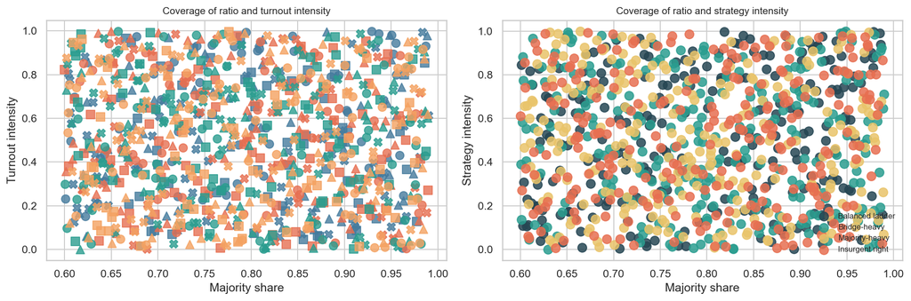

```python
plot_mixed_lhs_parameter_coverage(design_df);
```

## A few representative sampled cases

This section shows a small subset of the sampled cases to make the design intuitive to readers.

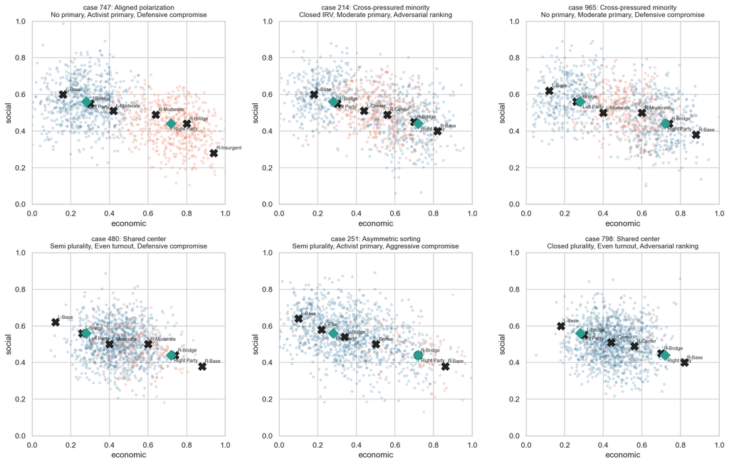

```python
plot_sample_case_gallery(design_df, n_show=6);
```

## Running the sampled design

Each sampled case is evaluated under all five compatible electoral systems. That expansion keeps plurality available as a within-case baseline instead of turning it into a separate experiment.

```python
results_df = run_mixed_lhs_grid(design_df, seed=BASE_SEED, n_voters=N_VOTERS)
results_df.shape
```

```
(5000, 40)
```

## System-level summary

This first summary averages across the sampled design. It should not be read as a universal ranking. It is just a compact way to see which systems tend to move outcomes toward the electorate center, and which ones tend to help or hurt welfare relative to their own matched no-primary baselines.

```python
system_summary = (
    results_df.groupby("system", as_index=False)
    .agg(
        mean_distance_to_median=("distance_to_median", "mean"),
        mean_aggregate_delta=("aggregate_welfare_delta_vs_no_primary", "mean"),
        mean_minority_delta=("minority_group_welfare_delta_vs_no_primary", "mean"),
    )
    .sort_values(["mean_distance_to_median", "mean_minority_delta"], ascending=[True, False])
    .reset_index(drop=True)
)
system_summary
```

|  | system | mean_distance_to_median | mean_aggregate_delta | mean_minority_delta |
| --- | --- | --- | --- | --- |
| 0 | Score | 0.108495 | -0.015592 | -0.039858 |
| 1 | Condorcet | 0.113214 | -0.010423 | -0.027980 |
| 2 | Approval | 0.113399 | -0.014789 | -0.032945 |
| 3 | Plurality | 0.114608 | -0.012493 | -0.025816 |
| 4 | IRV | 0.122844 | -0.005199 | -0.027736 |

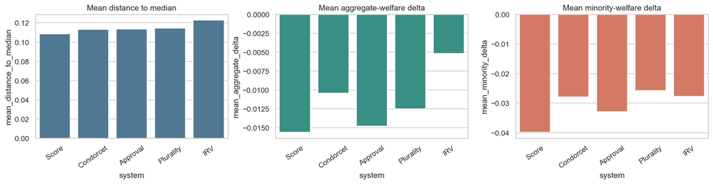

```python
fig, axes = plt.subplots(1, 3, figsize=(15, 4), dpi=150)

sns.barplot(data=system_summary, x="system", y="mean_distance_to_median", ax=axes[0], color="#457b9d")
axes[0].set_title("Mean distance to median")
axes[0].tick_params(axis="x", rotation=35)

sns.barplot(data=system_summary, x="system", y="mean_aggregate_delta", ax=axes[1], color="#2a9d8f")
axes[1].axhline(0.0, color="black", linewidth=1)
axes[1].set_title("Mean aggregate-welfare delta")
axes[1].tick_params(axis="x", rotation=35)

sns.barplot(data=system_summary, x="system", y="mean_minority_delta", ax=axes[2], color="#e76f51")
axes[2].axhline(0.0, color="black", linewidth=1)
axes[2].set_title("Mean minority-welfare delta")
axes[2].tick_params(axis="x", rotation=35)

fig.tight_layout()
```

## What changes once primaries are introduced

The next table averages by `primary × system`. Formally, it is summarizing estimates of the matched-baseline quantity

$$ \Delta_M(s, p) = \mathbb{E}_{Z}\left[M(s, p, Z) - M(s, \text{No primary}, Z)\right], $$

for different choices of metric $M$. So each cell is answering a question like: after averaging over the rest of the sampled political environment, what happens when this primary pipeline is added in front of this final electoral system?

```python
primary_summary = (
    results_df.groupby(["primary", "system"], as_index=False)
    .agg(
        mean_distance_to_median=("distance_to_median", "mean"),
        mean_aggregate_delta=("aggregate_welfare_delta_vs_no_primary", "mean"),
        mean_minority_delta=("minority_group_welfare_delta_vs_no_primary", "mean"),
    )
)
primary_summary
```

|  | primary | system | mean_distance_to_median | mean_aggregate_delta | mean_minority_delta |
| --- | --- | --- | --- | --- | --- |
| 0 | Closed IRV | Approval | 0.137962 | -0.025714 | -0.052621 |
| 1 | Closed IRV | Condorcet | 0.126864 | -0.015929 | -0.046287 |
| 2 | Closed IRV | IRV | 0.124394 | -0.003690 | -0.042738 |
| 3 | Closed IRV | Plurality | 0.126195 | -0.019280 | -0.036006 |
| 4 | Closed IRV | Score | 0.132716 | -0.023760 | -0.059740 |
| 5 | Closed plurality | Approval | 0.141626 | -0.026113 | -0.062050 |
| 6 | Closed plurality | Condorcet | 0.137323 | -0.021508 | -0.056055 |
| 7 | Closed plurality | IRV | 0.143271 | -0.018780 | -0.063452 |
| 8 | Closed plurality | Plurality | 0.137996 | -0.018086 | -0.046137 |
| 9 | Closed plurality | Score | 0.139918 | -0.027133 | -0.077582 |
| 10 | No primary | Approval | 0.070162 | 0.000000 | 0.000000 |
| 11 | No primary | Condorcet | 0.083442 | 0.000000 | 0.000000 |
| 12 | No primary | IRV | 0.106769 | 0.000000 | 0.000000 |
| 13 | No primary | Plurality | 0.076309 | 0.000000 | 0.000000 |
| 14 | No primary | Score | 0.057974 | 0.000000 | 0.000000 |
| 15 | Semi plurality | Approval | 0.137769 | -0.021841 | -0.043351 |
| 16 | Semi plurality | Condorcet | 0.128648 | -0.013875 | -0.045494 |
| 17 | Semi plurality | IRV | 0.131452 | -0.002195 | -0.036596 |
| 18 | Semi plurality | Plurality | 0.128937 | -0.015320 | -0.033949 |
| 19 | Semi plurality | Score | 0.139479 | -0.026145 | -0.057042 |
| 20 | Top-4 open | Approval | 0.079476 | -0.000276 | -0.006702 |
| 21 | Top-4 open | Condorcet | 0.089794 | -0.000802 | 0.007936 |
| 22 | Top-4 open | IRV | 0.108334 | -0.001327 | 0.004105 |
| 23 | Top-4 open | Plurality | 0.103601 | -0.009780 | -0.012986 |
| 24 | Top-4 open | Score | 0.072389 | -0.000923 | -0.004928 |

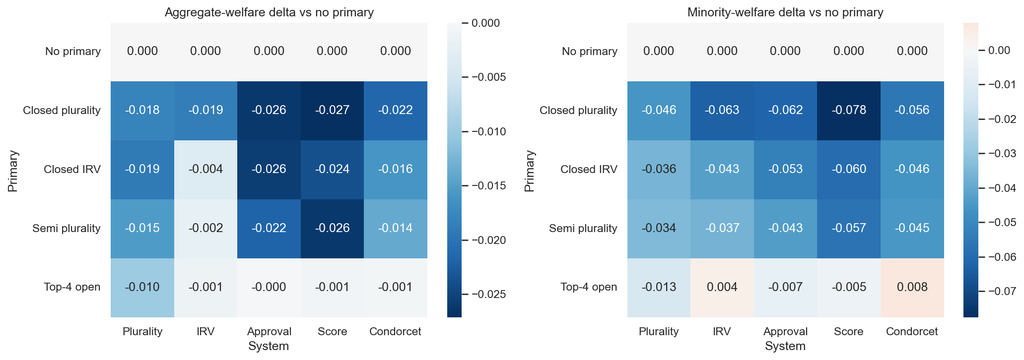

```python
fig, axes = plt.subplots(1, 2, figsize=(14, 5), dpi=150)
agg_pivot = primary_summary.pivot(index="primary", columns="system", values="mean_aggregate_delta").loc[PRIMARY_ORDER, SYSTEM_ORDER]
min_pivot = primary_summary.pivot(index="primary", columns="system", values="mean_minority_delta").loc[PRIMARY_ORDER, SYSTEM_ORDER]

sns.heatmap(agg_pivot, annot=True, fmt=".3f", cmap="RdBu_r", center=0.0, ax=axes[0])
axes[0].set_title("Aggregate-welfare delta vs no primary")
axes[0].set_xlabel("System")
axes[0].set_ylabel("Primary")

sns.heatmap(min_pivot, annot=True, fmt=".3f", cmap="RdBu_r", center=0.0, ax=axes[1])
axes[1].set_title("Minority-welfare delta vs no primary")
axes[1].set_xlabel("System")
axes[1].set_ylabel("Primary")

fig.tight_layout()
```

## Strategy sensitivity

The strategy profiles are still family-matched rather than literally identical across all systems. What changes here is that each sampled case also carries a strategy-intensity parameter, so the notebook is not just asking whether strategic pressure exists, but also how strongly it is present.

```python
strategy_summary = (
    results_df.groupby(["strategy", "system"], as_index=False)
    .agg(
        mean_distance_to_median=("distance_to_median", "mean"),
        mean_aggregate_delta=("aggregate_welfare_delta_vs_no_primary", "mean"),
        mean_minority_delta=("minority_group_welfare_delta_vs_no_primary", "mean"),
    )
)
strategy_summary
```

|  | strategy | system | mean_distance_to_median | mean_aggregate_delta | mean_minority_delta |
| --- | --- | --- | --- | --- | --- |
| 0 | Adversarial ranking | Approval | 0.109834 | -0.017659 | -0.046019 |
| 1 | Adversarial ranking | Condorcet | 0.126797 | -0.011091 | -0.048778 |
| 2 | Adversarial ranking | IRV | 0.137229 | 0.008589 | -0.059063 |
| 3 | Adversarial ranking | Plurality | 0.106004 | -0.013116 | -0.022876 |
| 4 | Adversarial ranking | Score | 0.108461 | -0.017313 | -0.047330 |
| 5 | Aggressive compromise | Approval | 0.113504 | -0.015678 | -0.032285 |
| 6 | Aggressive compromise | Condorcet | 0.124233 | -0.008558 | -0.014603 |
| 7 | Aggressive compromise | IRV | 0.130033 | -0.008981 | -0.003801 |
| 8 | Aggressive compromise | Plurality | 0.120586 | -0.016228 | -0.035410 |
| 9 | Aggressive compromise | Score | 0.111877 | -0.015625 | -0.036978 |
| 10 | Defensive compromise | Approval | 0.113891 | -0.014916 | -0.035059 |
| 11 | Defensive compromise | Condorcet | 0.103891 | -0.007089 | -0.013211 |
| 12 | Defensive compromise | IRV | 0.114519 | -0.007970 | -0.023245 |
| 13 | Defensive compromise | Plurality | 0.108972 | -0.013444 | -0.024623 |
| 14 | Defensive compromise | Score | 0.113848 | -0.014028 | -0.037254 |
| 15 | Sincere | Approval | 0.116366 | -0.010902 | -0.018416 |
| 16 | Sincere | Condorcet | 0.097936 | -0.014952 | -0.035328 |
| 17 | Sincere | IRV | 0.109595 | -0.012432 | -0.024837 |
| 18 | Sincere | Plurality | 0.122868 | -0.007185 | -0.020354 |
| 19 | Sincere | Score | 0.099795 | -0.015403 | -0.037871 |

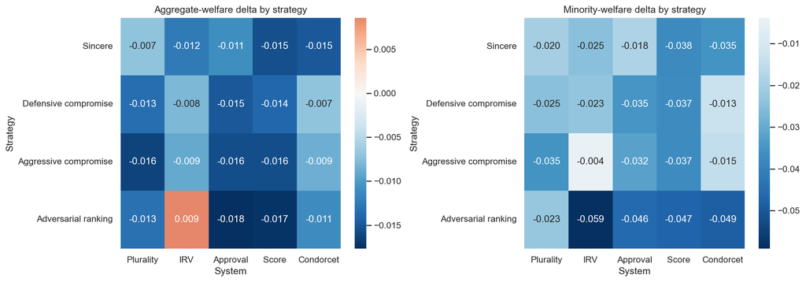

```python
fig, axes = plt.subplots(1, 2, figsize=(14, 5), dpi=150)
strategy_agg = strategy_summary.pivot(index="strategy", columns="system", values="mean_aggregate_delta").loc[STRATEGY_ORDER, SYSTEM_ORDER]
strategy_min = strategy_summary.pivot(index="strategy", columns="system", values="mean_minority_delta").loc[STRATEGY_ORDER, SYSTEM_ORDER]

sns.heatmap(strategy_agg, annot=True, fmt=".3f", cmap="RdBu_r", center=0.0, ax=axes[0])
axes[0].set_title("Aggregate-welfare delta by strategy")
axes[0].set_xlabel("System")
axes[0].set_ylabel("Strategy")

sns.heatmap(strategy_min, annot=True, fmt=".3f", cmap="RdBu_r", center=0.0, ax=axes[1])
axes[1].set_title("Minority-welfare delta by strategy")
axes[1].set_xlabel("System")
axes[1].set_ylabel("Strategy")

fig.tight_layout()
```

## Every system against plurality

Plurality is the baseline, so every other system is compared to plurality within the same sampled case. Positive values mean the system is doing better than plurality on that metric.

```python
plurality_df = plurality_comparison_table(results_df)
plurality_summary = (
    plurality_df.groupby("system", as_index=False)
    .agg(
        mean_distance_gain_vs_plurality=("distance_gain_vs_plurality", "mean"),
        mean_aggregate_gain_vs_plurality=("aggregate_gain_vs_plurality", "mean"),
        mean_minority_gain_vs_plurality=("minority_gain_vs_plurality", "mean"),
    )
    .sort_values(["mean_distance_gain_vs_plurality", "mean_minority_gain_vs_plurality"], ascending=False)
    .reset_index(drop=True)
)
plurality_summary
```

|  | system | mean_distance_gain_vs_plurality | mean_aggregate_gain_vs_plurality | mean_minority_gain_vs_plurality |
| --- | --- | --- | --- | --- |
| 0 | Score | 0.006112 | 0.002326 | 0.016473 |
| 1 | Condorcet | 0.001393 | 0.000510 | 0.003413 |
| 2 | Approval | 0.001209 | 0.000243 | 0.013876 |
| 3 | Plurality | 0.000000 | 0.000000 | 0.000000 |
| 4 | IRV | -0.008236 | -0.002574 | 0.003367 |

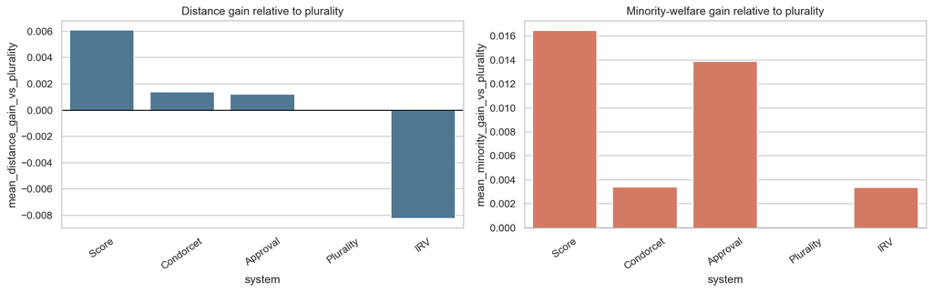

```python
fig, axes = plt.subplots(1, 2, figsize=(14, 4.5), dpi=150)

sns.barplot(data=plurality_summary, x="system", y="mean_distance_gain_vs_plurality", ax=axes[0], color="#457b9d")
axes[0].axhline(0.0, color="black", linewidth=1)
axes[0].set_title("Distance gain relative to plurality")
axes[0].tick_params(axis="x", rotation=35)

sns.barplot(data=plurality_summary, x="system", y="mean_minority_gain_vs_plurality", ax=axes[1], color="#e76f51")
axes[1].axhline(0.0, color="black", linewidth=1)
axes[1].set_title("Minority-welfare gain relative to plurality")
axes[1].tick_params(axis="x", rotation=35)

fig.tight_layout()
```

## How regressions like this are used in social science

The summary tables above are good for broad comparisons, but they do not tell us which ingredients matter most once several political forces move together. In social science, a common next step is to fit a regression model that summarizes average associations while adjusting for the other observed variables in the dataset.

A first instinct is often to remove one block at a time and see how much $R^2$ falls. But that becomes hard to interpret when the regressors overlap heavily. In this notebook, the interaction terms are deliberately built from the main effects, so blocks like `primary × system` inevitably share explanatory power with `primary` and `system` on their own. That means a simple leave-one-block-out drop can make some terms look artificially unimportant just because nearby terms are soaking up the same variance.

To handle that more carefully, the notebook now uses a **Shapley-style $R^2$ decomposition**. For a term family $g$, its contribution is averaged over many possible orderings of the model blocks:

$$ \phi_g = \frac{1}{|\Pi|} \sum_{\pi \in \Pi} \left[ R^2\bigl(S_{\pi}(g) \cup \{g\}\bigr) - R^2\bigl(S_{\pi}(g)\bigr) \right], $$

where $S_{\pi}(g)$ is the set of term families that appear before $g$ in ordering $\pi$. Intuitively, this asks: across many different ways of building the model up piece by piece, how much extra fit does this block contribute on average?

The notebook still uses a descriptive linear model rather than a causal one:

$$ Y_i = \alpha + \sum_g X_{ig} \beta_g + \sum_h Z_{ih} \gamma_h + \varepsilon_i, $$

where the $X$ terms are main effects and transformed continuous covariates, and the $Z$ terms are selected interaction blocks. The continuous quantities are treated more flexibly than before:

- minority share,
- turnout intensity,
- strategy intensity.

Each one is centered, scaled, and entered both linearly and quadratically. So the model is allowed to represent curved relationships instead of forcing everything onto a straight line.

The notebook looks at four outcomes:

- overall welfare, $W_{\mathrm{agg}}$,
- majority welfare, $W_{\mathrm{maj}}$,
- minority welfare, $W_{\mathrm{min}}$,
- the normalized minority-minus-majority welfare gap,

$$ \frac{W_{\mathrm{min}} - W_{\mathrm{maj}}}{|W_{\mathrm{agg}}|}. $$

Using $|W_{\mathrm{agg}}|$ in the denominator keeps the gap on a comparable scale across sampled cases, so a given vertical change means roughly the same thing in a high-welfare case and a low-welfare case.

Computing exact Shapley values for every subset of the full term list would be expensive, so the notebook uses a permutation approximation: it samples many orderings, averages the marginal contributions, and then normalizes them within each outcome:

$$ S_g = \frac{\phi_g}{R^2_{\mathrm{full}}}. $$

So the heatmap below should be read as a relative decomposition of the explained signal for each outcome. Larger values mean that block accounts for more of the fitted $R^2$ once overlap between correlated blocks is averaged over more fairly.

```python
results_df = results_df.copy()
normalization_scale = results_df["aggregate_welfare"].abs().clip(lower=1e-9)
results_df["normalized_minority_minus_majority_welfare"] = (
    results_df["minority_group_welfare"] - results_df["majority_group_welfare"]
) / normalization_scale

regression_targets = [
    ("aggregate_welfare", "Overall welfare"),
    ("majority_group_welfare", "Majority welfare"),
    ("minority_group_welfare", "Minority welfare"),
    (
        "normalized_minority_minus_majority_welfare",
        "Normalized minority-minus-majority welfare",
    ),
]

regression_importance_df = shapley_regression_importance(
    results_df,
    regression_targets,
    n_permutations=REGRESSION_SHAPLEY_PERMUTATIONS,
    seed=BASE_SEED,
)
regression_fit_summary = (
    regression_importance_df[["outcome", "full_r2"]]
    .drop_duplicates()
    .reset_index(drop=True)
)

display(regression_fit_summary)
regression_importance_df[["outcome", "term_family", "shapley_r2", "shapley_share", "full_r2"]]
```

|  | outcome | full_r2 |
| --- | --- | --- |
| 0 | Majority welfare | 0.583271 |
| 1 | Minority welfare | 0.755557 |
| 2 | Normalized minority-minus-majority welfare | 0.663499 |
| 3 | Overall welfare | 0.796275 |

|  | outcome | term_family | shapley_r2 | shapley_share | full_r2 |
| --- | --- | --- | --- | --- | --- |
| 0 | Majority welfare | electorate × primary | 0.191012 | 0.327483 | 0.583271 |
| 1 | Majority welfare | electorate | 0.184842 | 0.316905 | 0.583271 |
| 2 | Majority welfare | electorate × system | 0.156642 | 0.268558 | 0.583271 |
| 3 | Majority welfare | turnout profile × primary | 0.014653 | 0.025121 | 0.583271 |
| 4 | Majority welfare | strategy profile × system | 0.010196 | 0.017481 | 0.583271 |
| 5 | Majority welfare | turnout profile × system | 0.005993 | 0.010274 | 0.583271 |
| 6 | Majority welfare | primary × system | 0.005311 | 0.009105 | 0.583271 |
| 7 | Majority welfare | turnout profile | 0.003850 | 0.006601 | 0.583271 |
| 8 | Majority welfare | turnout intensity × turnout profile | 0.002357 | 0.004041 | 0.583271 |
| 9 | Majority welfare | minority share × primary | 0.001940 | 0.003325 | 0.583271 |
| 10 | Majority welfare | strategy profile | 0.001598 | 0.002739 | 0.583271 |
| 11 | Majority welfare | turnout intensity | 0.001280 | 0.002194 | 0.583271 |
| 12 | Majority welfare | strategy intensity × strategy profile | 0.001048 | 0.001798 | 0.583271 |
| 13 | Majority welfare | strategy intensity | 0.000740 | 0.001268 | 0.583271 |
| 14 | Majority welfare | minority share | 0.000710 | 0.001218 | 0.583271 |
| 15 | Majority welfare | system | 0.000289 | 0.000495 | 0.583271 |
| 16 | Majority welfare | primary | 0.000283 | 0.000486 | 0.583271 |
| 17 | Majority welfare | candidate slate | 0.000270 | 0.000462 | 0.583271 |
| 18 | Majority welfare | minority share × system | 0.000261 | 0.000447 | 0.583271 |
| 19 | Minority welfare | electorate × primary | 0.244150 | 0.323139 | 0.755557 |
| 20 | Minority welfare | electorate | 0.230148 | 0.304607 | 0.755557 |
| 21 | Minority welfare | electorate × system | 0.194561 | 0.257507 | 0.755557 |
| 22 | Minority welfare | turnout profile × primary | 0.031764 | 0.042041 | 0.755557 |
| 23 | Minority welfare | turnout profile × system | 0.010375 | 0.013731 | 0.755557 |
| 24 | Minority welfare | turnout profile | 0.008878 | 0.011751 | 0.755557 |
| 25 | Minority welfare | primary × system | 0.008859 | 0.011726 | 0.755557 |
| 26 | Minority welfare | primary | 0.007849 | 0.010388 | 0.755557 |
| 27 | Minority welfare | strategy profile × system | 0.004375 | 0.005791 | 0.755557 |
| 28 | Minority welfare | turnout intensity × turnout profile | 0.003851 | 0.005097 | 0.755557 |
| 29 | Minority welfare | strategy intensity × strategy profile | 0.003014 | 0.003989 | 0.755557 |
| 30 | Minority welfare | minority share × primary | 0.002594 | 0.003433 | 0.755557 |
| 31 | Minority welfare | candidate slate | 0.001963 | 0.002599 | 0.755557 |
| 32 | Minority welfare | strategy intensity | 0.001342 | 0.001776 | 0.755557 |
| 33 | Minority welfare | strategy profile | 0.000632 | 0.000837 | 0.755557 |
| 34 | Minority welfare | minority share | 0.000479 | 0.000634 | 0.755557 |
| 35 | Minority welfare | system | 0.000286 | 0.000379 | 0.755557 |
| 36 | Minority welfare | minority share × system | 0.000284 | 0.000376 | 0.755557 |
| 37 | Minority welfare | turnout intensity | 0.000151 | 0.000200 | 0.755557 |
| 38 | Normalized minority-minus-majority welfare | electorate × primary | 0.218965 | 0.330016 | 0.663499 |
| 39 | Normalized minority-minus-majority welfare | electorate | 0.214670 | 0.323543 | 0.663499 |
| 40 | Normalized minority-minus-majority welfare | electorate × system | 0.182532 | 0.275106 | 0.663499 |
| 41 | Normalized minority-minus-majority welfare | turnout profile × primary | 0.008854 | 0.013344 | 0.663499 |
| 42 | Normalized minority-minus-majority welfare | strategy profile × system | 0.007725 | 0.011642 | 0.663499 |
| 43 | Normalized minority-minus-majority welfare | primary × system | 0.005051 | 0.007613 | 0.663499 |
| 44 | Normalized minority-minus-majority welfare | turnout profile × system | 0.004132 | 0.006228 | 0.663499 |
| 45 | Normalized minority-minus-majority welfare | minority share × primary | 0.004116 | 0.006204 | 0.663499 |
| 46 | Normalized minority-minus-majority welfare | primary | 0.003102 | 0.004675 | 0.663499 |
| 47 | Normalized minority-minus-majority welfare | minority share | 0.002412 | 0.003635 | 0.663499 |
| 48 | Normalized minority-minus-majority welfare | turnout profile | 0.002303 | 0.003470 | 0.663499 |
| 49 | Normalized minority-minus-majority welfare | strategy intensity × strategy profile | 0.001914 | 0.002884 | 0.663499 |
| 50 | Normalized minority-minus-majority welfare | strategy profile | 0.001581 | 0.002382 | 0.663499 |
| 51 | Normalized minority-minus-majority welfare | minority share × system | 0.001516 | 0.002284 | 0.663499 |
| 52 | Normalized minority-minus-majority welfare | turnout intensity × turnout profile | 0.001514 | 0.002283 | 0.663499 |
| 53 | Normalized minority-minus-majority welfare | strategy intensity | 0.001318 | 0.001986 | 0.663499 |
| 54 | Normalized minority-minus-majority welfare | candidate slate | 0.000759 | 0.001144 | 0.663499 |
| 55 | Normalized minority-minus-majority welfare | turnout intensity | 0.000629 | 0.000948 | 0.663499 |
| 56 | Normalized minority-minus-majority welfare | system | 0.000406 | 0.000611 | 0.663499 |
| 57 | Overall welfare | electorate × primary | 0.240729 | 0.302319 | 0.796275 |
| 58 | Overall welfare | electorate | 0.236931 | 0.297549 | 0.796275 |
| 59 | Overall welfare | electorate × system | 0.197645 | 0.248212 | 0.796275 |
| 60 | Overall welfare | turnout profile × primary | 0.049124 | 0.061692 | 0.796275 |
| 61 | Overall welfare | turnout profile × system | 0.016661 | 0.020923 | 0.796275 |
| 62 | Overall welfare | turnout profile | 0.015524 | 0.019496 | 0.796275 |
| 63 | Overall welfare | primary × system | 0.009873 | 0.012400 | 0.796275 |
| 64 | Overall welfare | turnout intensity × turnout profile | 0.007903 | 0.009924 | 0.796275 |
| 65 | Overall welfare | primary | 0.007715 | 0.009689 | 0.796275 |
| 66 | Overall welfare | strategy profile × system | 0.003109 | 0.003905 | 0.796275 |
| 67 | Overall welfare | minority share | 0.002874 | 0.003609 | 0.796275 |
| 68 | Overall welfare | strategy intensity × strategy profile | 0.002005 | 0.002518 | 0.796275 |
| 69 | Overall welfare | candidate slate | 0.001786 | 0.002242 | 0.796275 |
| 70 | Overall welfare | minority share × primary | 0.001285 | 0.001613 | 0.796275 |
| 71 | Overall welfare | strategy profile | 0.001100 | 0.001382 | 0.796275 |
| 72 | Overall welfare | minority share × system | 0.000759 | 0.000953 | 0.796275 |
| 73 | Overall welfare | turnout intensity | 0.000723 | 0.000908 | 0.796275 |
| 74 | Overall welfare | strategy intensity | 0.000439 | 0.000551 | 0.796275 |
| 75 | Overall welfare | system | 0.000091 | 0.000114 | 0.796275 |

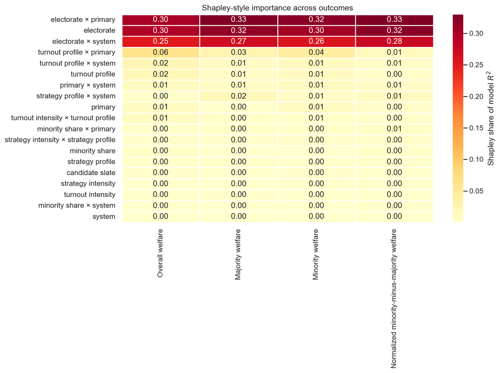

```python
importance_heatmap = (
    regression_importance_df
    .pivot(index="term_family", columns="outcome", values="shapley_share")
    .fillna(0.0)
)
importance_heatmap = importance_heatmap.loc[
    importance_heatmap.mean(axis=1).sort_values(ascending=False).index,
    [label for _, label in regression_targets],
]

fig, ax = plt.subplots(figsize=(11, 8), dpi=150)
sns.heatmap(
    importance_heatmap,
    annot=True,
    fmt=".2f",
    cmap="YlOrRd",
    linewidths=0.5,
    ax=ax,
    cbar_kws={"label": "Shapley share of model $R^2$"},
)
ax.set_title("Shapley-style importance across outcomes")
ax.set_xlabel("")
ax.set_ylabel("")
fig.tight_layout()
```

## How the normalized minority-majority gap changes as the minority shrinks

The regression summary is only one way to look at the data. Because minority share is one of the continuous dimensions in the Latin hypercube, it is also useful to look at it directly.

The next figure goes back to a line-style view. Minority share is binned into evenly populated groups, and each point shows the average normalized gap inside one bin for one electoral system. The shaded band shows the middle half of the sampled cases in that bin, so the figure still gives some sense of spread while making the overall trend easier to read.

The y-axis uses a normalized minority-minus-majority welfare gap,

$$ \frac{W_{\mathrm{min}} - W_{\mathrm{maj}}}{|W_{\mathrm{agg}}|}. $$

Values near zero mean the two groups are doing similarly. More negative values mean the minority is doing worse than the majority, relative to the overall scale of welfare in that sampled case.

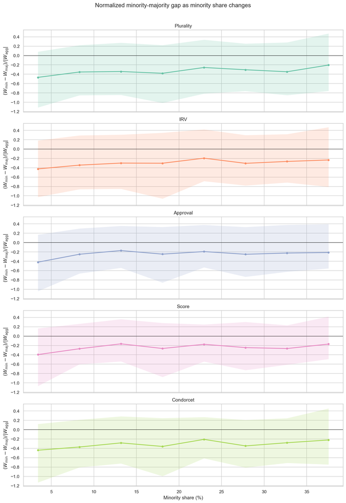

```python
plot_gap_vs_minority_share(results_df);
```

### Conclusion

A few broad patterns stand out once the notebook is averaged over `1000` sampled cases. First, primaries are not just a neutral first step. Relative to each system's own matched no-primary baseline, almost every primary pipeline reduces overall welfare on average, and minority welfare usually falls even more. The broad political message is simple: filtering the field before the general election often does real damage, even when the final election rule stays the same.

Second, the kind of primary matters more than the final election rule in many of these comparisons. `Top-4 open` is clearly the least damaging pipeline in the notebook. Its aggregate and minority-welfare deltas stay much closer to zero than the closed pipelines, and for minority welfare it is the only pipeline that occasionally turns positive on average, as in `Top-4 open + Condorcet` and `Top-4 open + IRV`. By contrast, the closed pipelines are much harsher, especially for minority voters. The worst minority average in the notebook comes from `Closed plurality + Score`, and several other closed combinations are not far behind. For a lay reader, that points to an intuitive lesson: broadening who reaches the general election can matter more than changing how the final round is counted.

Third, different comparisons reward different systems. If the question is which rule keeps the most value relative to its own no-primary baseline, `IRV` looks surprisingly resilient on aggregate welfare, with the smallest average aggregate loss among the five systems. But if the question is which rule outperforms plurality inside the same sampled setting, `Score` is the clearest winner: it has the best average distance-to-median improvement, the best aggregate-welfare gain over plurality, and the largest minority-welfare gain over plurality. `Approval` also modestly improves on plurality, while `IRV` actually does worse than plurality on average distance and aggregate welfare in that direct comparison. So the notebook does not end with one universal champion. It ends with a more interesting point: whether a system looks good depends on what baseline is being used.

Finally, the notebook now keeps the focus squarely on overall, majority, and minority welfare. The Shapley-style decomposition asks where explanatory power lives once overlapping institutional and strategic factors are averaged over more fairly. The minority-share diagnostic complements that by tracing how the normalized minority-majority gap moves as the minority becomes smaller. Together, those views make the notebook less about naming one best system and more about identifying which political conditions widen or narrow the welfare gap between large and small groups.